# An extended look at crime (types) in Phoenix in 2020

### What about the increase in 2020?

Inspection of the 2020 data aggregated over crime types indicates that by the end of 2020, we were roughly back to the same level of crime incidents being reported as the beginning of the year.

Looking at the plots, we can see what types of crimes drove this increase.

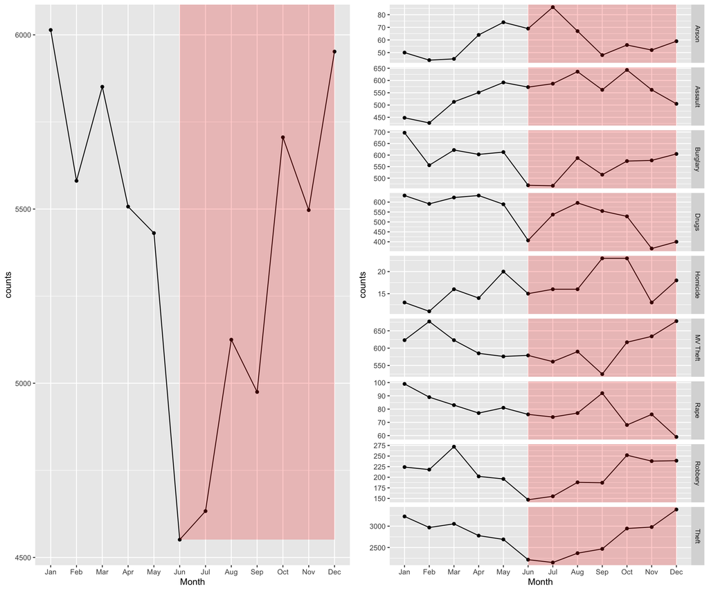

Increase were mainly driven by an increase, *initially*, in **Drugs**. Later period increase was mainly driven by **Robbery**, **Motor Vehicle (MV) Theft**, and **Theft**. Gradual increases were seen for **Burglary**.

#### Plotting the data (**code**)

```r
grid.arrange(
  p2020 +
    geom_rect( aes( xmin=6, xmax=12, ymin=min( crimes.by.month$counts ), ymax=Inf ), alpha = 0.02, fill = "red" ) ,
  p2020t +
    geom_rect( aes( xmin=6, xmax=12, ymin=-Inf, ymax=Inf ), alpha = 0.02, fill = "red" ) ,
ncol = 2 )
```

### Difference from 2019?

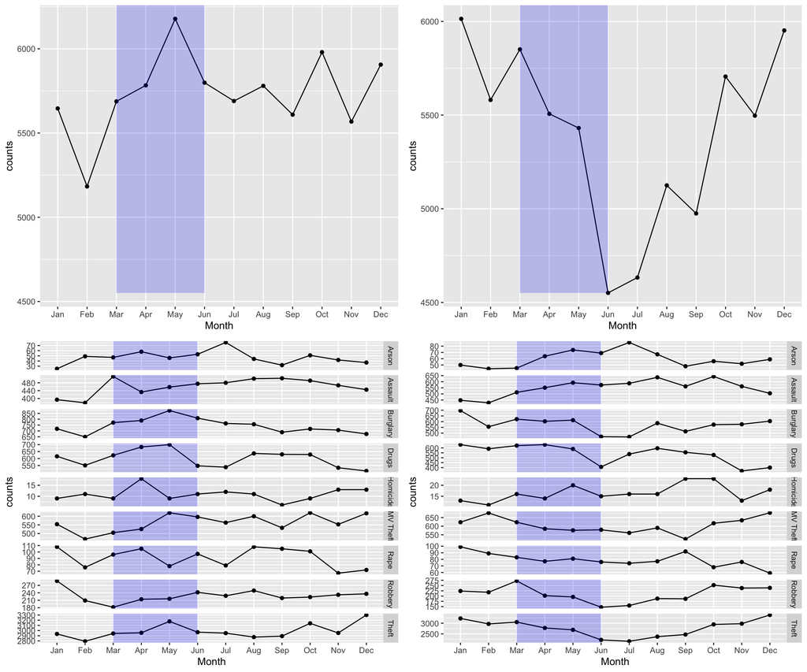

#### Plotting the data (**code**)

```r
p2019 <- crimes.by.month %>%
  filter( year == 2019 ) %>%  # take just the 2019 data.
  ggplot( aes( month, counts, group = 1 ) ) +
  geom_point( ) +
  geom_line( ) +
  xlab( "Month" )

p2019t <- crimes.type.by.month %>%
  filter( year == 2019 ) %>%  # take just the 2019 data.
  ggplot( aes( month, counts, group = 1 ) ) +
  geom_point( ) +
  geom_line( ) +
  facet_grid( rows = vars( crime.type ), scales="free" ) +
  theme( #axis.text.x=element_blank(),
         #strip.text.x = element_text( size = 15 ),
         strip.text.y = element_text( size = 8 ) ) +
  xlab( "Month" )

grid.arrange(
  p2019 +
    geom_rect( aes( xmin=3, xmax=6, ymin=min( crimes.by.month$counts ), ymax=Inf ), alpha = 0.02, fill = "blue" ) ,
  p2020 +
    geom_rect( aes( xmin=3, xmax=6, ymin=min( crimes.by.month$counts ), ymax=Inf ), alpha = 0.02, fill = "blue" ) ,
  p2019t +
    geom_rect( aes( xmin=3, xmax=6, ymin=-Inf, ymax=Inf ), alpha = 0.02, fill = "blue" ) ,
  p2020t +
    geom_rect( aes( xmin=3, xmax=6, ymin=-Inf, ymax=Inf ), alpha = 0.02, fill = "blue" ) ,
ncol = 2, nrow = 2 )
```

[Back to R 2 Phoenix page](https://jacobtnyoung.github.io/R2PhX/)

*Please* report any needed corrections to the [Issues](https://github.com/jacobtnyoung/R2PhX/issues/new) page. Thanks!

*Last updated 14 February, 2024*